# Homework-1

Ömer Anıl Usta

06 11 2020

## Homework1

### 1)Daily Births and the Search for Baby Names

#### We have a data of the daily births in US from 2000 to 2014.

#### Lets check daily birth frequencies in the months of the year 2014, and see if there are any differences.

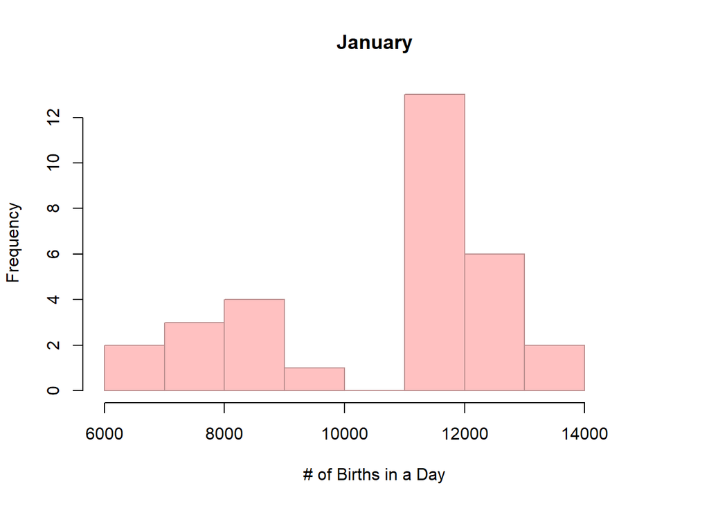

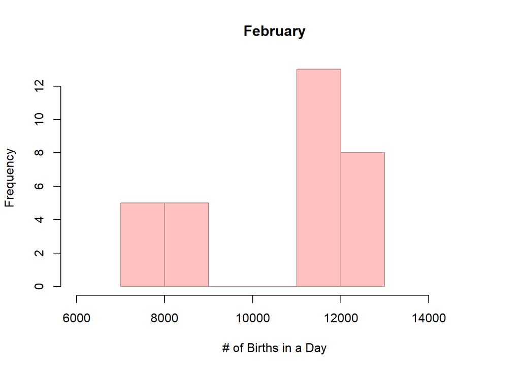

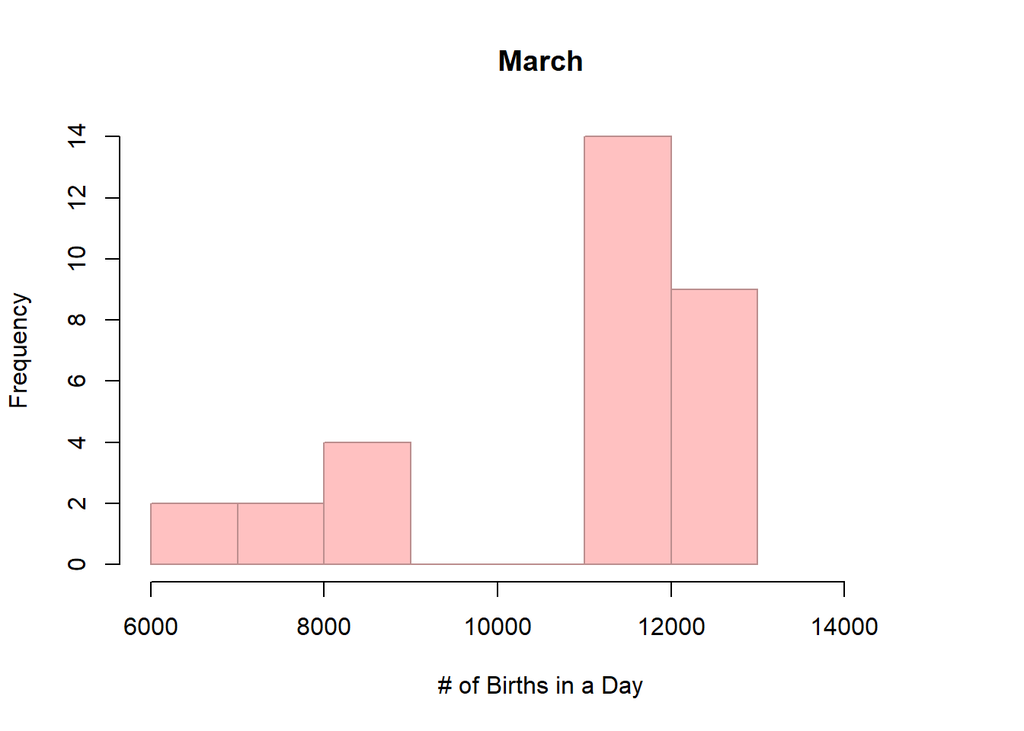

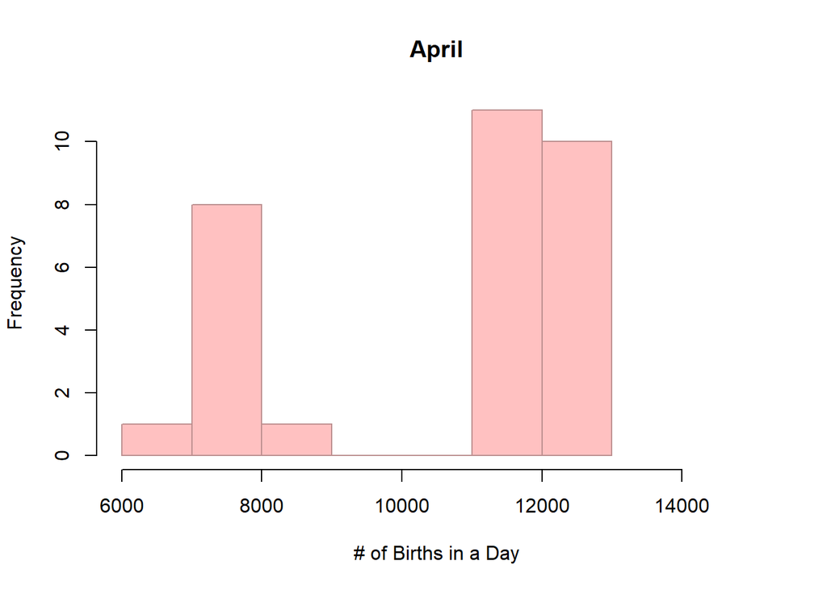

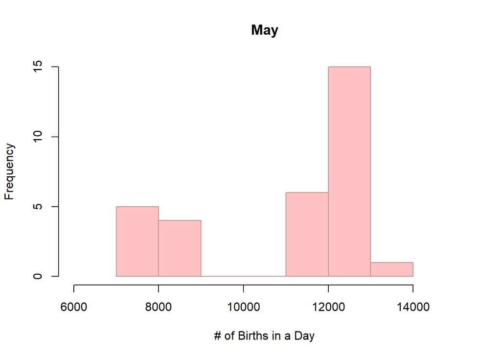

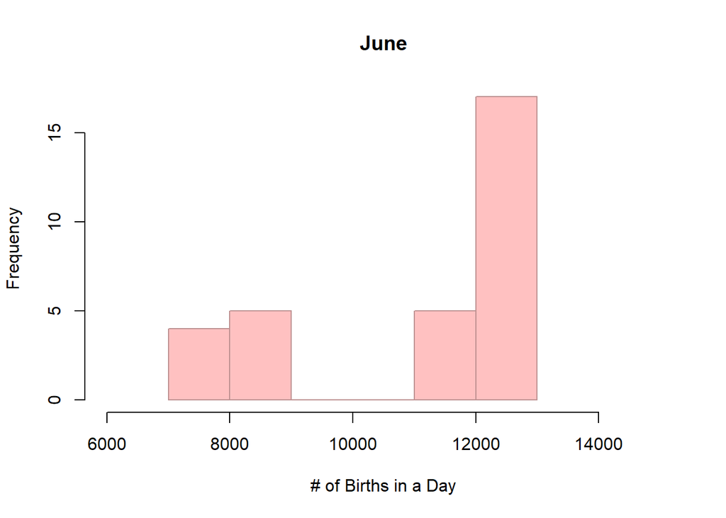

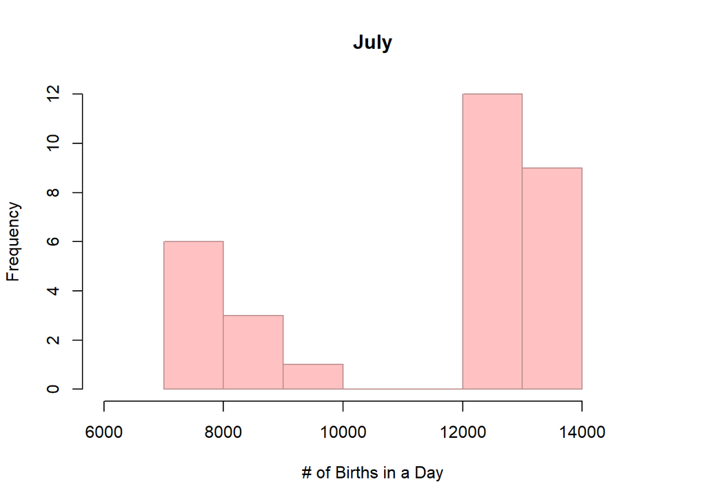

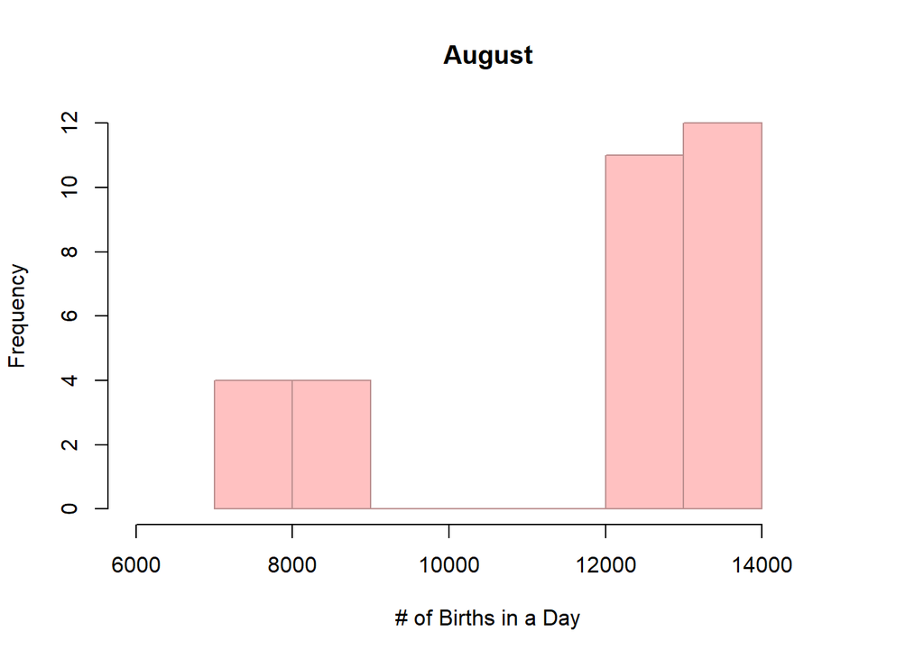

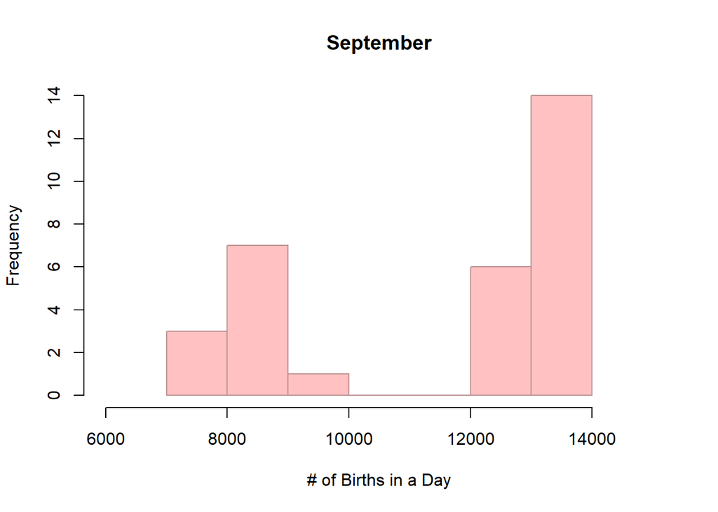

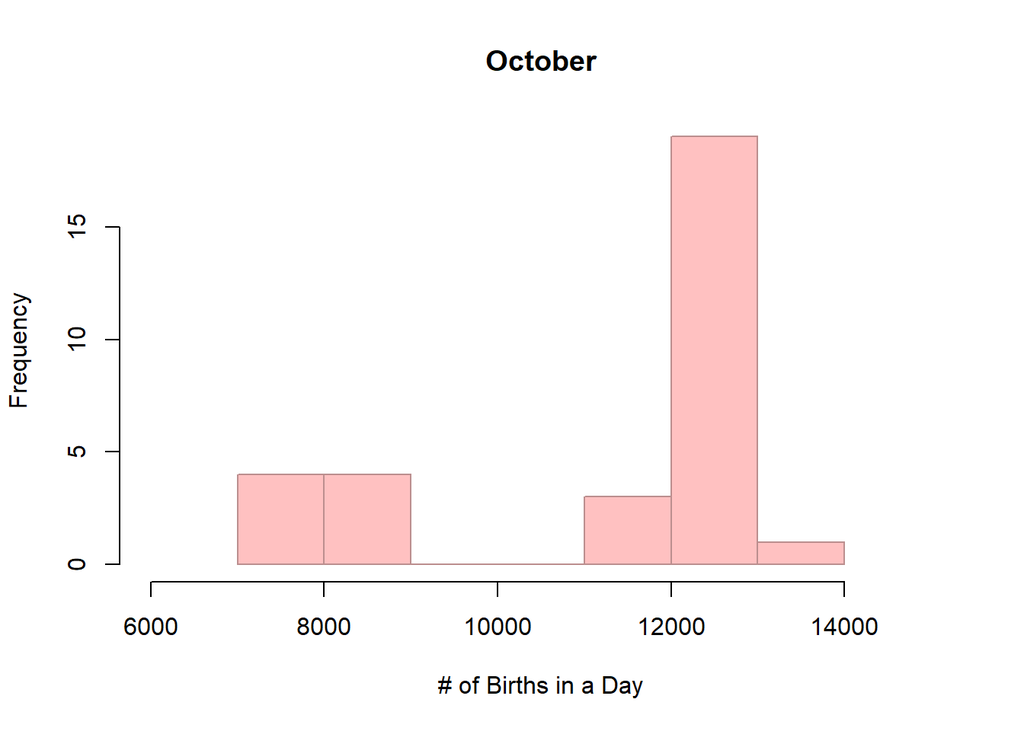

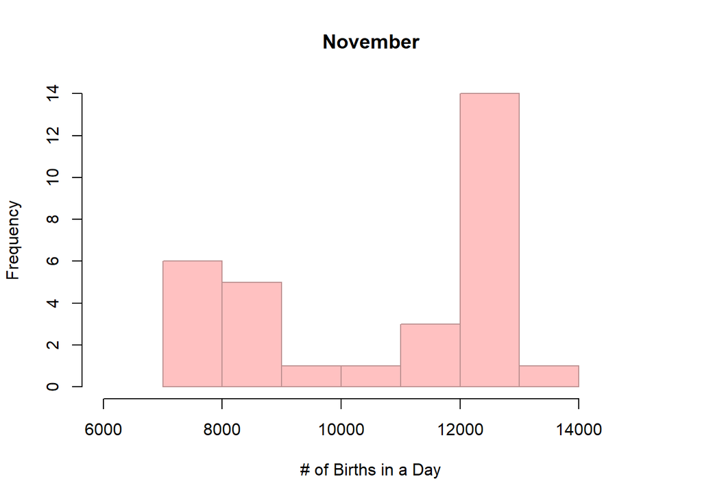

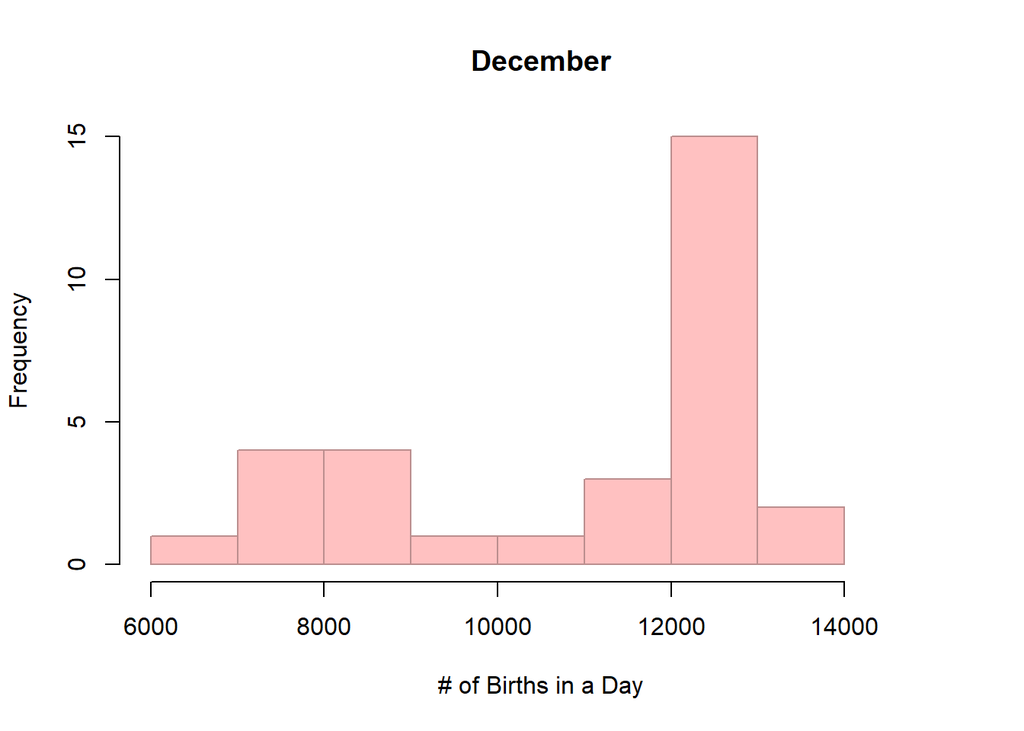

#### After looking at these histograms, we can say some months have more births than others.

#### Now lets look at the year 2014 as a whole. In the boxplot graph below: July, August and September has the most births compared to other months.

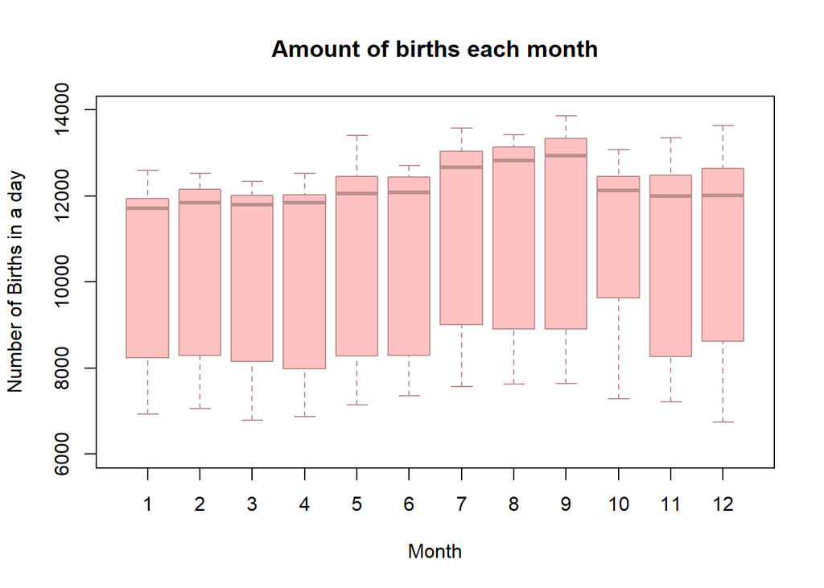

[figure not shown]

#### If we look a the boxplot raph in popularity of “baby names” in Google, we observe leading up to the boom of births in July, August and September; for July many people were looking for a name for their future baby. Interesting thing is popularity of baby names near Christmas and the New Year.

### 2)Average Temperature and the Searchor for Sunscreen

#### Next we have a data about the weather temperatures in United States from July of 2014 to June of 2015.

#### Now lets look at the frequency histograms of temperatures of weather in Fahrenheit for the months in this period of time. We will focus on the actual mean temperature.

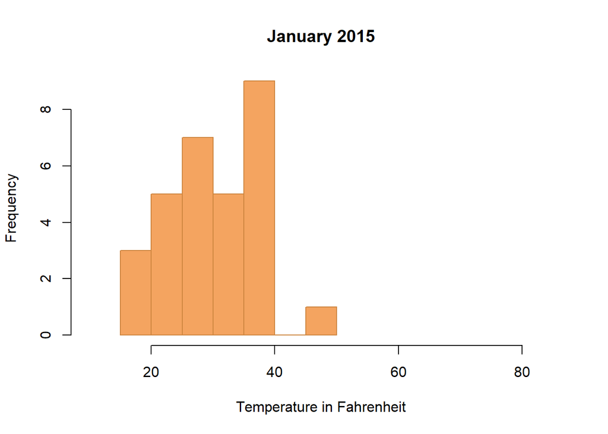

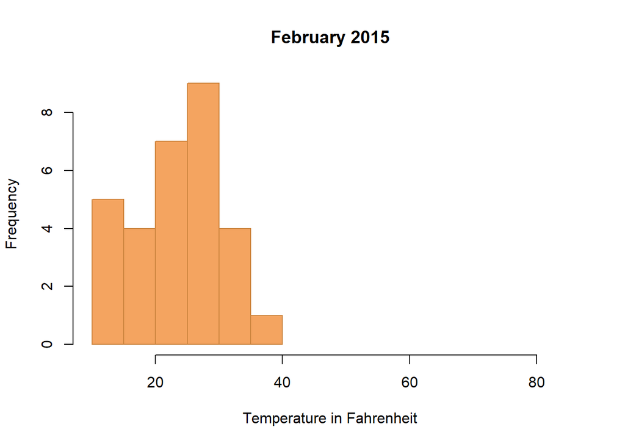

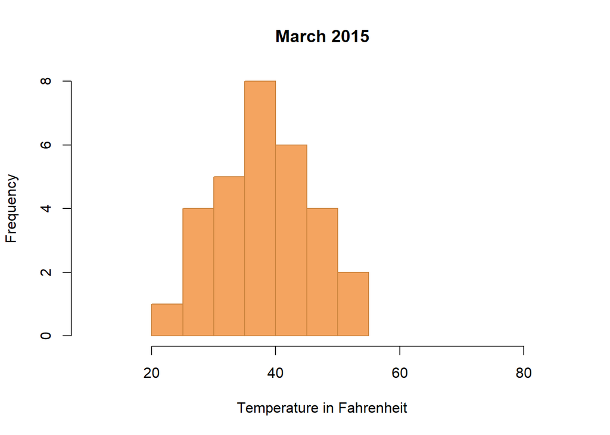

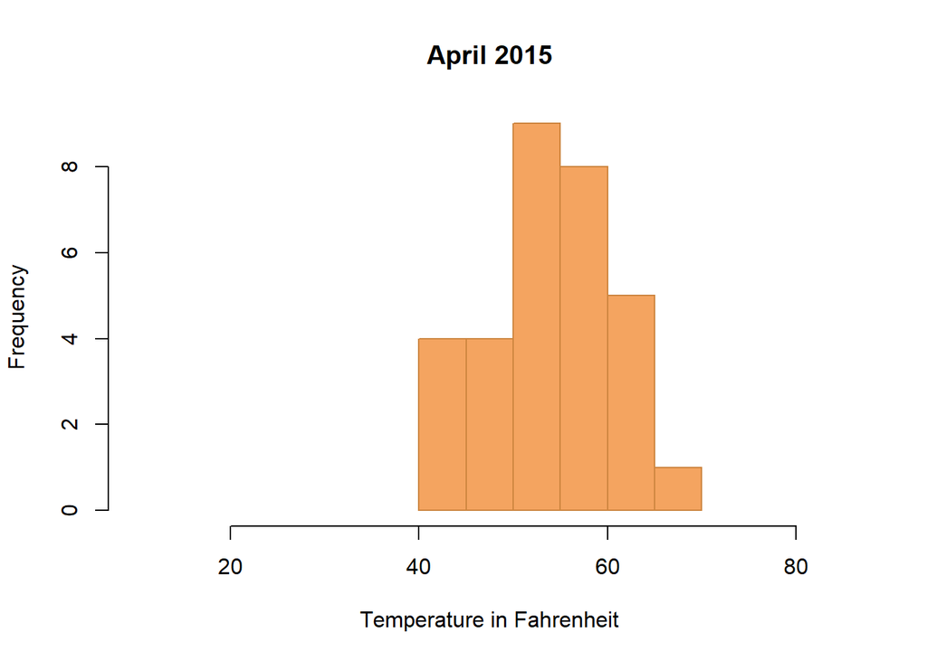

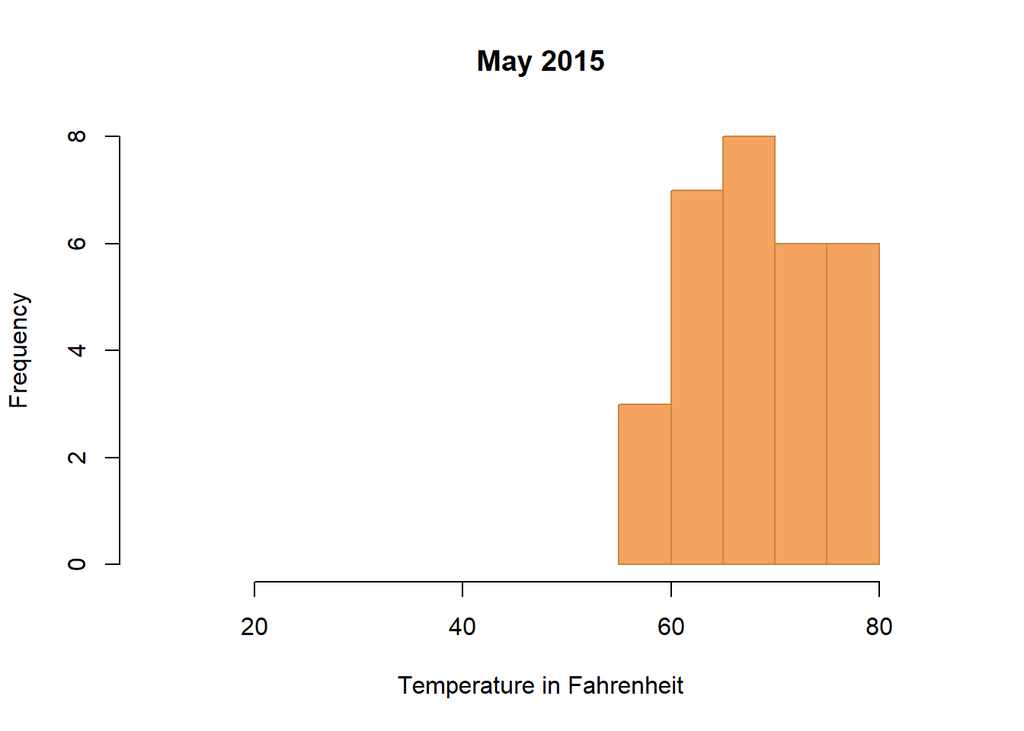

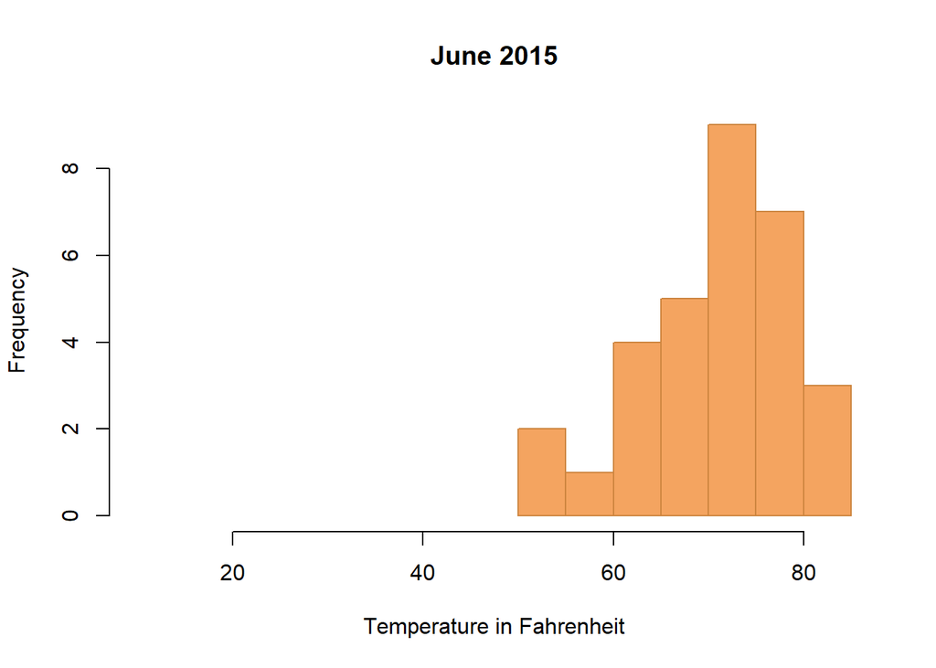

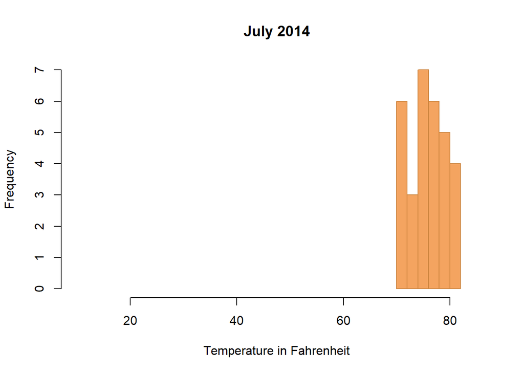

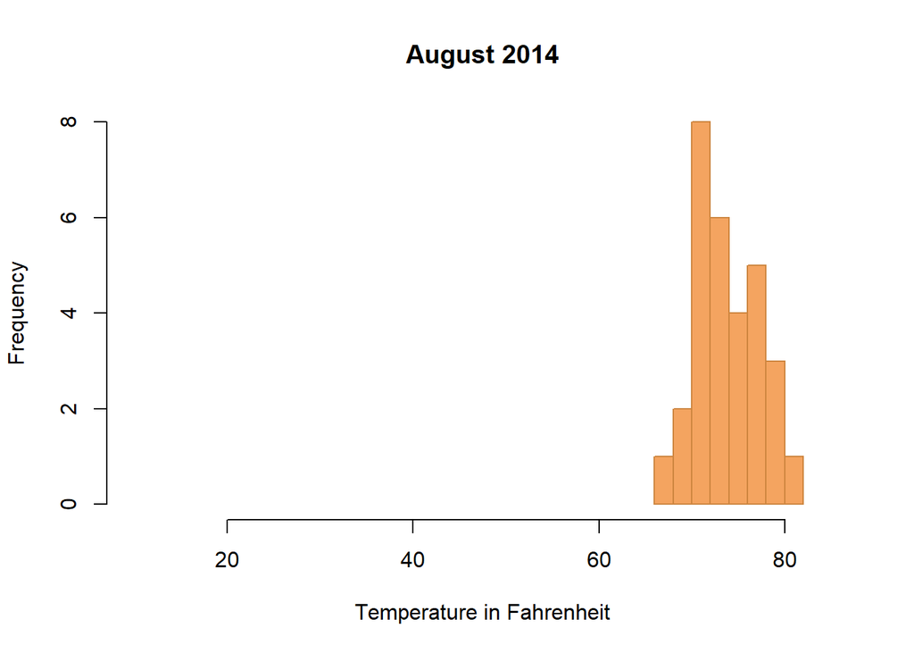

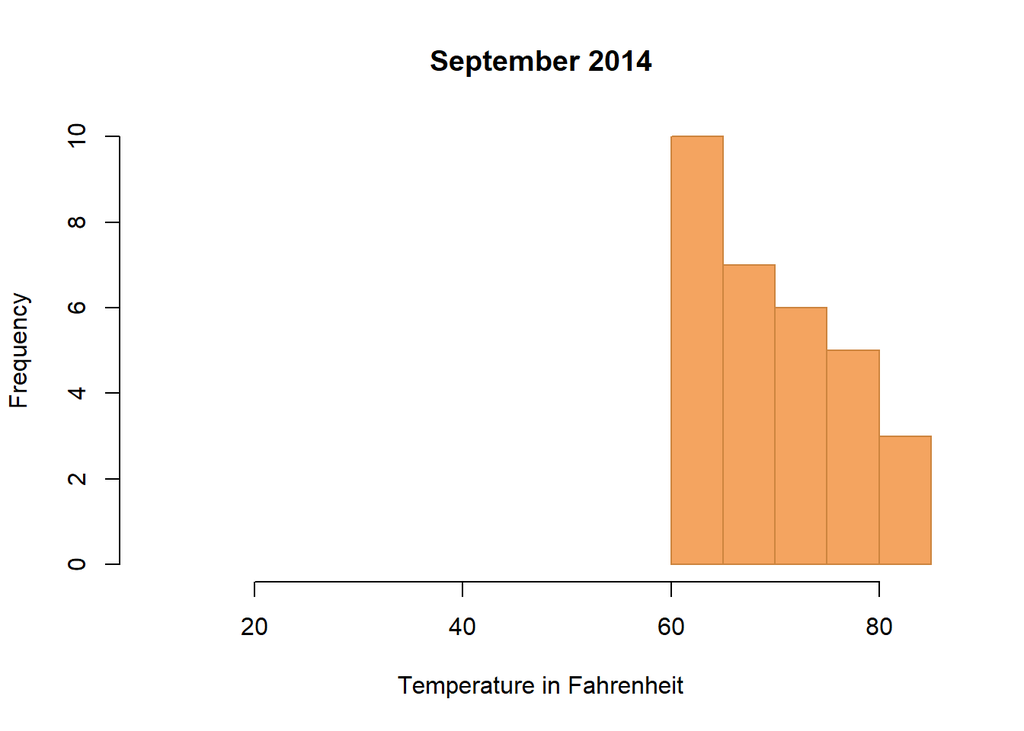

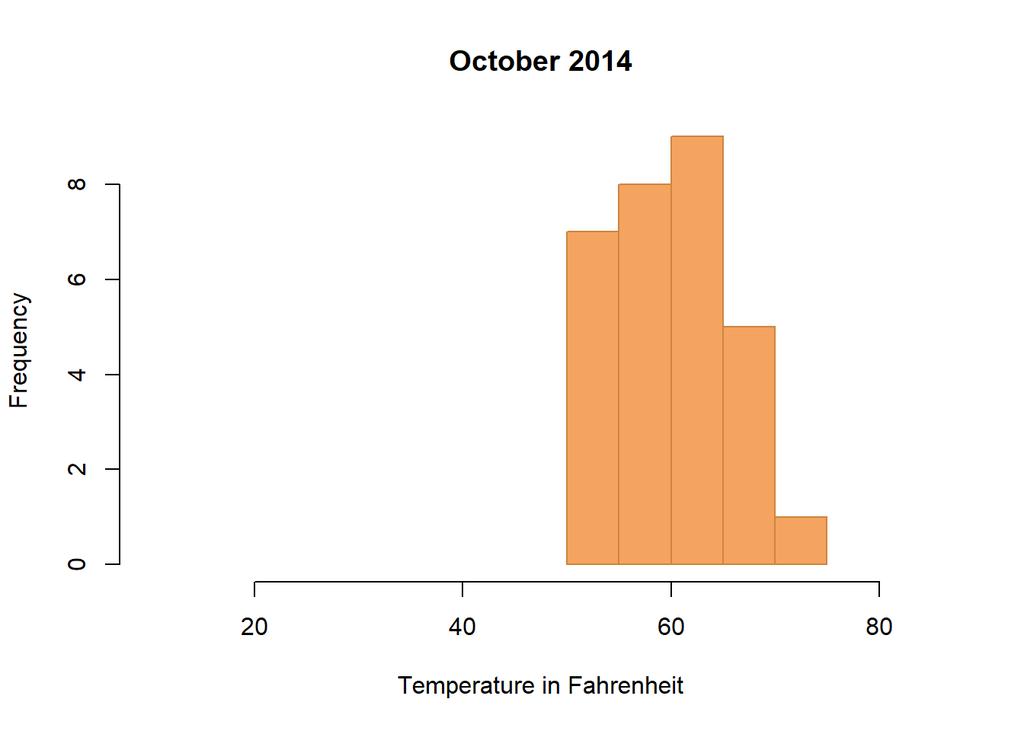

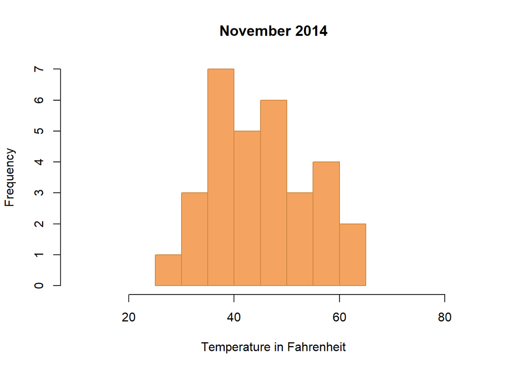

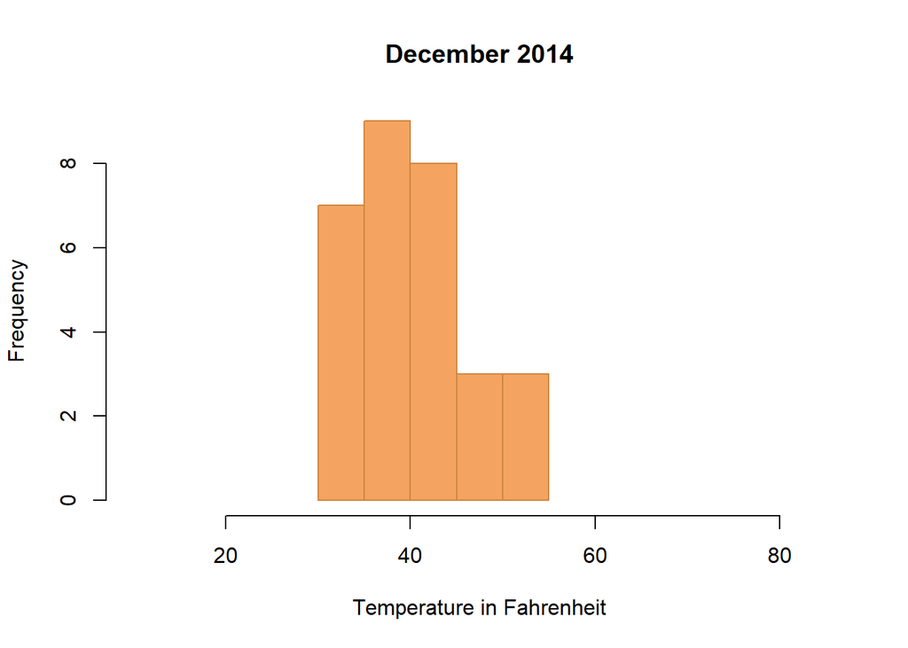

#### Now lets see the months next to each other and compare. As expected summer months have higher temperature while the beginning and the end of the year is colder.

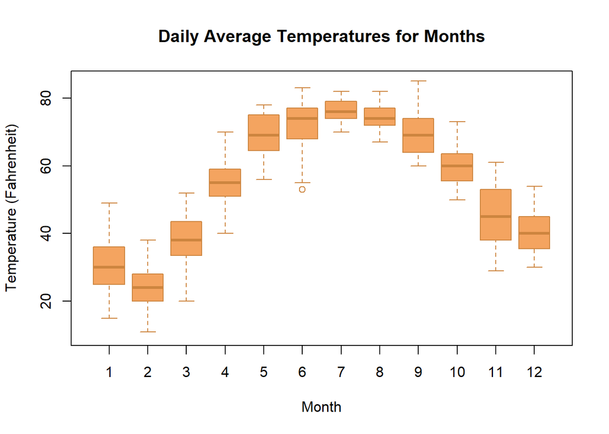

[figure not shown]

#### We observe the search for “sunscreen” increases drastically when the temperatures start rising.

### 3)Emergency Calls About Hurricane Sandy and the Search for Shelter

#### On October 22nd 2012, Hurricane Sandy hit New York and cost $65 billion dollars worth of destruction. The state of had prepared a phone number for emergencies. Lets see week by week the calls that was made to this number 3-1-1.

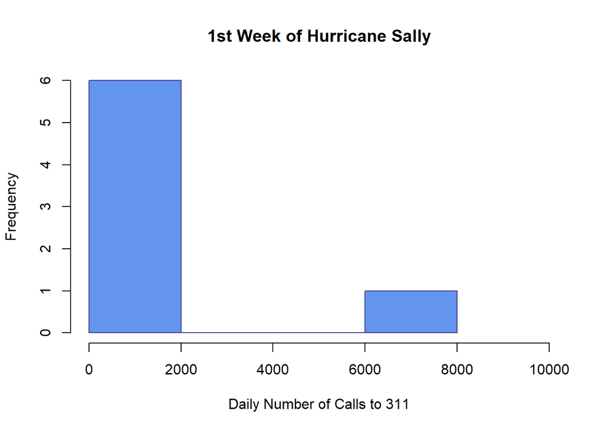

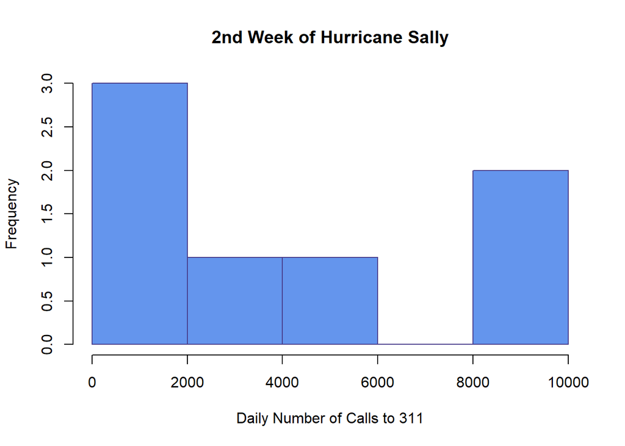

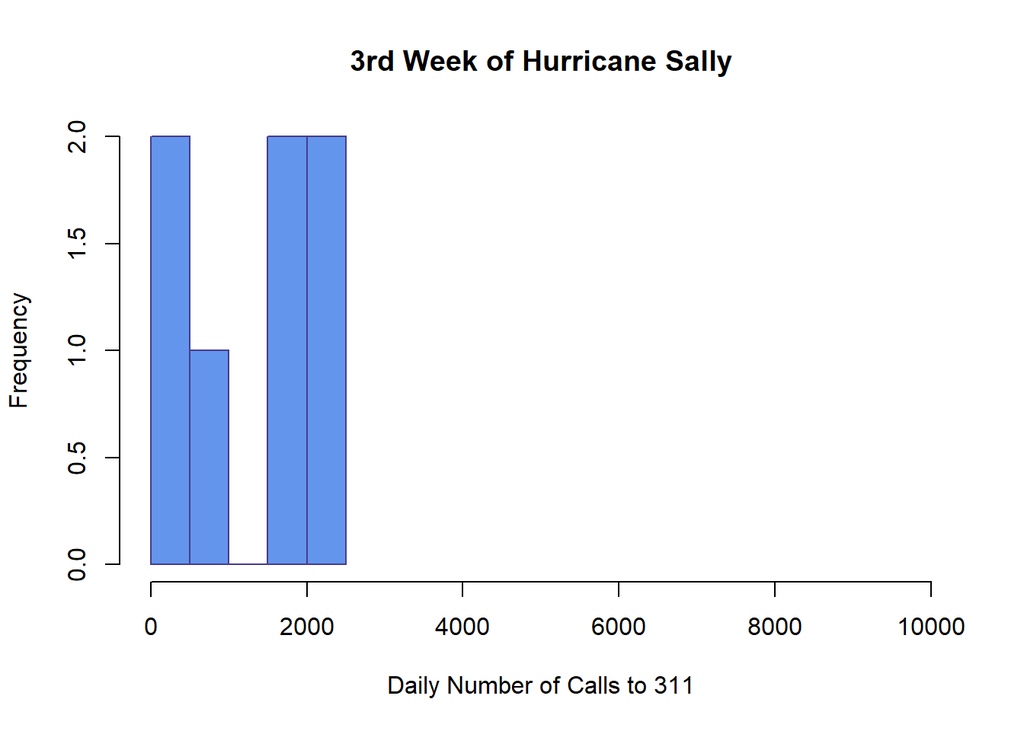

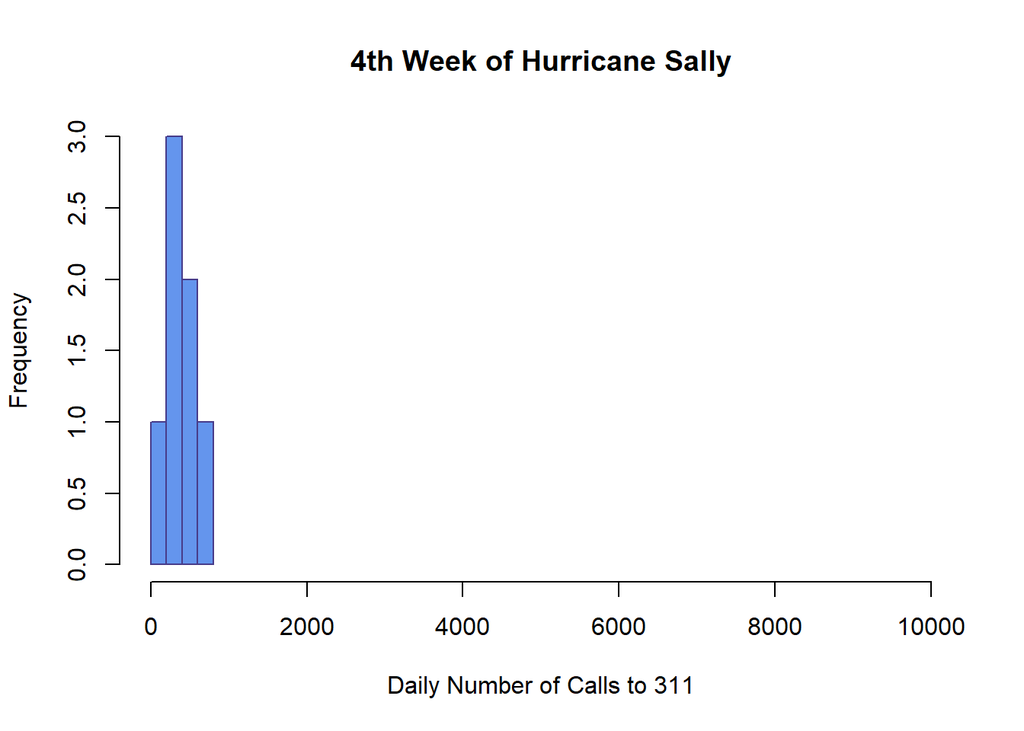

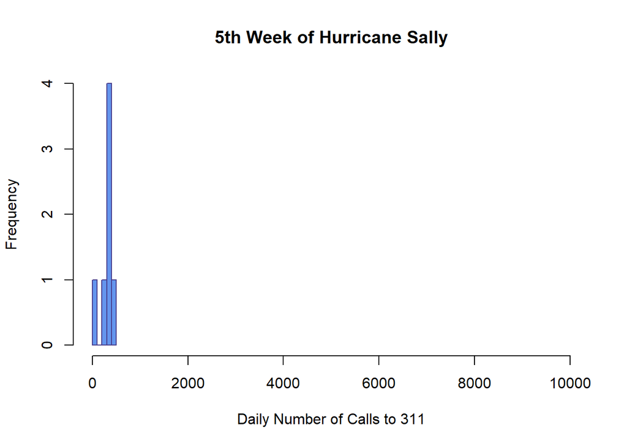

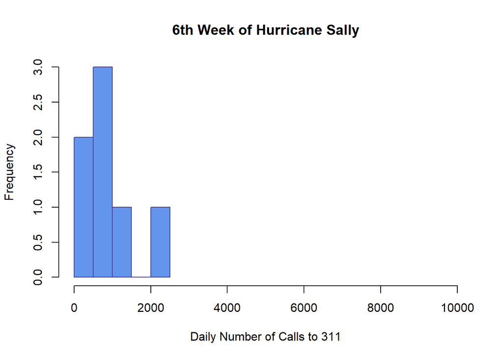

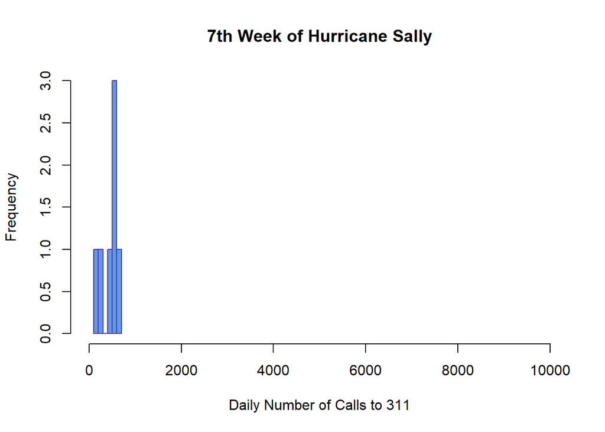

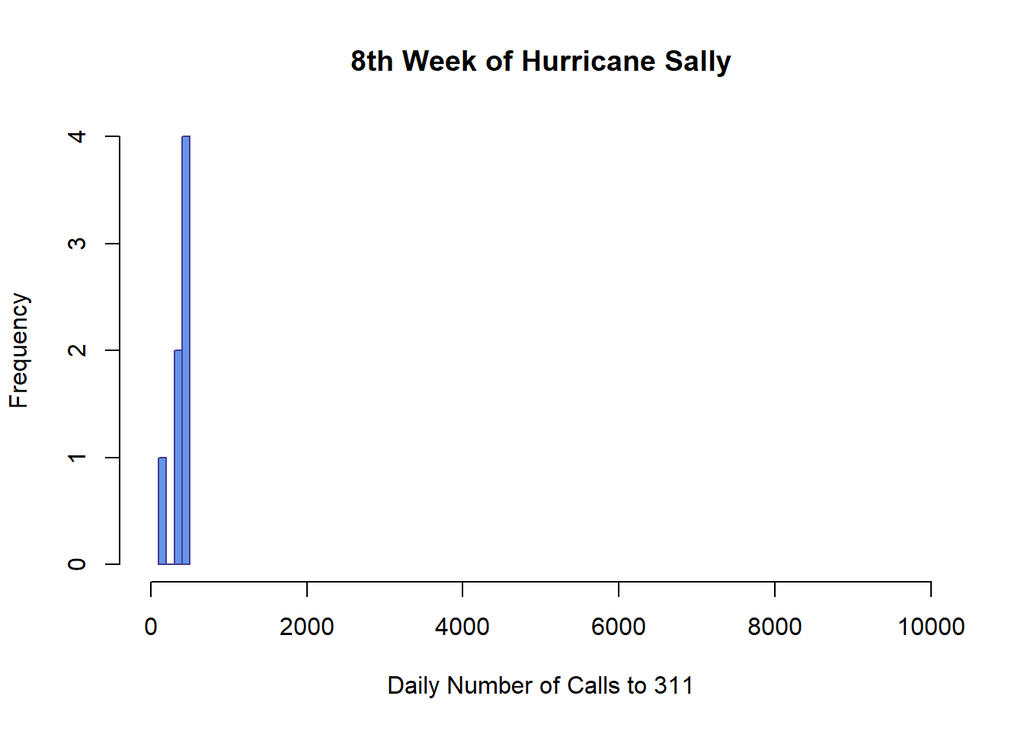

[figure not shown]

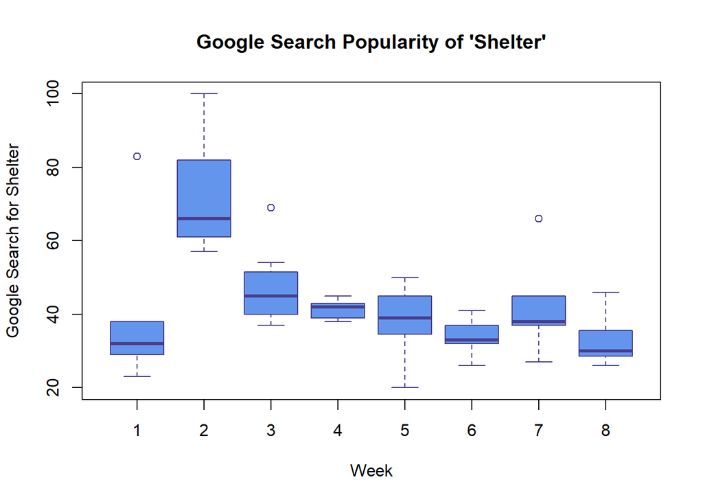

#### We see that the look for shelter skyrocketed when the hurricane started heating up.